# Notebook3_Propuesta_EDA

### Análisis Exploratorio, Comparativo y Contraste de Hipótesis

```python
import pandas as pd
import numpy as np

pd.options.mode.copy_on_write = True # CoW por defecto a partir de Pandas 3.0.0

import matplotlib.pyplot as plt
import seaborn as sns

from scipy.stats import chi2_contingency
from scipy.stats import kruskal
```

```python
# Carga de datasets limpios
# se desactiva low_memory para evitar warnings por tipos mixtos)

licencias = pd.read_csv(
    "./datasets/Licencias_2024y2025_limpio.csv",
    parse_dates=["fechanacimiento", "fechaaltasolicitud"],
    low_memory=False
)
```

```python
siniestros = pd.read_csv(
    "./datasets/Siniestros_limpio.csv",
    parse_dates=["fechaparteaccidente", "fechaaltaparte"],
    low_memory=False
)
```

```python
licencias.info()
```

```
<class 'pandas.core.frame.DataFrame'>
RangeIndex: 18915 entries, 0 to 18914
Data columns (total 17 columns):
 #   Column                         Non-Null Count  Dtype
---  ------                         --------------  -----
 0   nif                            18915 non-null  object
 1   sexo                           18915 non-null  object
 2   fechanacimiento                18915 non-null  datetime64[ns]
 3   descripcionprovinciadomicilio  18915 non-null  object
 4   fechaaltasolicitud             18915 non-null  datetime64[ns]
 5   temporada                      18915 non-null  int64
 6   modalidad                      18915 non-null  object
 7   categoria                      18915 non-null  object
 8   importecomplemento             18915 non-null  int64
 9   importefmm                     18915 non-null  float64
 10  importeseguro                  18915 non-null  float64
 11  importefederacionesp           18915 non-null  float64
 12  importedescuento               18915 non-null  int64
 13  importeampliacion              18915 non-null  float64
 14  cuota_socio                    18915 non-null  int64
 15  discapacidad                   18915 non-null  object
 16  edad                           18915 non-null  int64
dtypes: datetime64[ns](2), float64(4), int64(5), object(6)
memory usage: 2.5+ MB
```

```python
siniestros.info()
```

```
<class 'pandas.core.frame.DataFrame'>
RangeIndex: 631 entries, 0 to 630
Data columns (total 17 columns):
 #   Column               Non-Null Count  Dtype
---  ------               --------------  -----
 0   nif                  631 non-null    object
 1   fechaparteaccidente  631 non-null    datetime64[ns]
 2   fechaaltaparte       631 non-null    datetime64[ns]
 3   codigo               631 non-null    int64
 4   actividad            631 non-null    object
 5   lugar                631 non-null    object
 6   fecharecepcion       631 non-null    object
 7   entrenamiento        631 non-null    bool
 8   actividadpersonal    631 non-null    bool
 9   actividadorganizada  631 non-null    bool
 10  festivo              631 non-null    bool
 11  nresponsables        631 non-null    int64
 12  tamañogrupo          631 non-null    int64
 13  descripciongrado     631 non-null    object
 14  pais                 631 non-null    object
 15  provincia            631 non-null    object
 16  tipoaccidente        631 non-null    object
dtypes: bool(4), datetime64[ns](2), int64(3), object(8)
memory usage: 66.7+ KB
```

### Creación del dataset analítico

```python
df_analisis = siniestros.merge(
    licencias[
        [
            "nif",
            "modalidad",   # ← tipo de seguro
            "sexo",
            "edad",
            "categoria",
            "temporada"
        ]
    ],
    on="nif",
    how="left"
)
```

```python
df_analisis.info()
```

```
<class 'pandas.core.frame.DataFrame'>
RangeIndex: 631 entries, 0 to 630
Data columns (total 22 columns):
 #   Column               Non-Null Count  Dtype
---  ------               --------------  -----
 0   nif                  631 non-null    object
 1   fechaparteaccidente  631 non-null    datetime64[ns]
 2   fechaaltaparte       631 non-null    datetime64[ns]
 3   codigo               631 non-null    int64
 4   actividad            631 non-null    object
 5   lugar                631 non-null    object
 6   fecharecepcion       631 non-null    object
 7   entrenamiento        631 non-null    bool
 8   actividadpersonal    631 non-null    bool
 9   actividadorganizada  631 non-null    bool
 10  festivo              631 non-null    bool
 11  nresponsables        631 non-null    int64
 12  tamañogrupo          631 non-null    int64
 13  descripciongrado     631 non-null    object
 14  pais                 631 non-null    object
 15  provincia            631 non-null    object
 16  tipoaccidente        631 non-null    object
 17  modalidad            631 non-null    object
 18  sexo                 631 non-null    object
 19  edad                 631 non-null    int64
 20  categoria            631 non-null    object
 21  temporada            631 non-null    int64
dtypes: bool(4), datetime64[ns](2), int64(5), object(11)
memory usage: 91.3+ KB
```

```python
df_analisis.head()
```

[output not shown]

### Limpieza analítica focalizada

```python
# Eliminación de nulos SOLO en variables clave

df_analisis = df_analisis.dropna(
    subset=["modalidad", "descripciongrado"]
)
```

```python
df_analisis.isnull().sum()
```

```
nif                    0
fechaparteaccidente    0
fechaaltaparte         0
codigo                 0
actividad              0
lugar                  0
fecharecepcion         0
entrenamiento          0
actividadpersonal      0
actividadorganizada    0
festivo                0
nresponsables          0
tamañogrupo            0
descripciongrado       0
pais                   0
provincia              0
tipoaccidente          0
modalidad              0
sexo                   0
edad                   0
categoria              0
temporada              0
dtype: int64
```

### Tratamiento de valores nulos en el dataset analítico

La eliminación de valores nulos se realizó de forma selectiva, atendiendo exclusivamente a las variables directamente implicadas en las hipótesis planteadas.

En concreto, se eliminaron únicamente los registros con valores nulos en:

- `modalidad`, variable explicativa principal (tipo de seguro).
- `descripciongrado`, variable respuesta que mide la gravedad del accidente.

Esta decisión se adopta para garantizar la validez del análisis comparativo y de los contrastes estadísticos, evitando al mismo tiempo una pérdida innecesaria de información en variables no críticas para los objetivos del estudio.

Los valores nulos en otras variables se conservaron al no interferir en la respuesta a la pregunta de investigación.

### Análisis UNIVARIANTE

#### Distribución de gravedad del siniestro

Se analiza la distribución de la variable `descripciongrado` para identificar la frecuencia de siniestros leves, graves y mortales, proporcionando una primera visión del perfil general de la siniestralidad.

```python
df_analisis["descripciongrado"].value_counts(dropna=False)
```

```
descripciongrado
LEVE      526
GRAVE      57
NAN        42
MORTAL      6
Name: count, dtype: int64
```

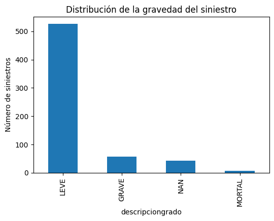

```python
df_analisis["descripciongrado"].value_counts().plot(
    kind="bar",
    figsize=(6,4),
    title="Distribución de la gravedad del siniestro"
)
plt.ylabel("Número de siniestros")
plt.show()
```

Análisis de la gravedad de los siniestros

La distribución de la gravedad de los siniestros muestra un claro predominio de los accidentes leves, que representan la gran mayoría de los casos registrados en el dataset.

Los accidentes graves constituyen una proporción significativamente menor, mientras que los accidentes mortales son muy poco frecuentes. La categoría NAN corresponde a registros en los que no se dispone de información sobre el grado de gravedad del siniestro.

Esta distribución indica que, aunque la ocurrencia de siniestros es elevada, la mayor parte de ellos no presenta consecuencias de alta gravedad, si bien la presencia de valores sin clasificar debe tenerse en cuenta en los análisis posteriores.

## Distribución por modalidad de seguro

Se estudia la distribución de los siniestros según la modalidad del seguro contratado, con el objetivo de identificar qué tipos de seguro concentran un mayor número de accidentes.

```python
df_analisis["modalidad"].value_counts()
```

```
modalidad
B     481
C      95
D      26
A      16
AU      5
B6      4
A6      3
OT      1
Name: count, dtype: int64
```

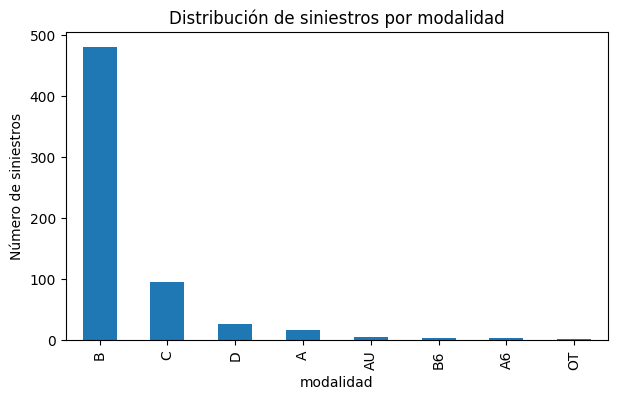

```python
df_analisis["modalidad"].value_counts().plot(
    kind="bar",
    figsize=(7,4),
    title="Distribución de siniestros por modalidad"
)
plt.ylabel("Número de siniestros")
plt.show()
```

**Distribución de seguros por modalidad**

Las modalidades AU, B6, A6 y OT tienen una representación marginal, lo que indica que se trata de productos poco frecuentes o específicos dentro del conjunto analizado.

Esta distribución refleja una fuerte concentración de los asegurados en un número reducido de modalidades, aspecto relevante a tener en cuenta en los análisis comparativos posteriores, ya que las modalidades minoritarias pueden no contar con suficiente volumen para extraer conclusiones robustas.

## Distribución de edad

Se examina la distribución de la edad de los federados implicados en siniestros, permitiendo detectar patrones demográficos relevantes para el análisis posterior.

```python
df_analisis["edad"].describe()
```

```
count    631.000000
mean      48.413629
std       15.008518
min        5.000000
25%       38.000000
50%       49.000000
75%       60.000000
max       89.000000
Name: edad, dtype: float64
```

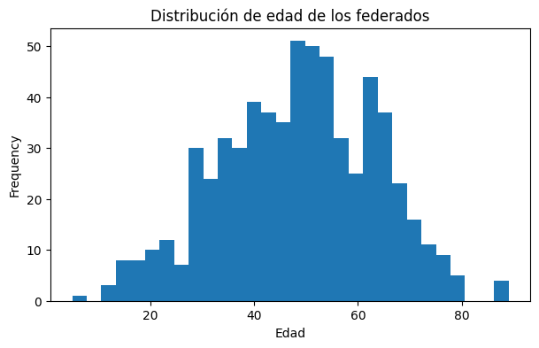

```python
df_analisis["edad"].plot(
    kind="hist",
    bins=30,
    figsize=(7,4),
    title="Distribución de edad de los federados"
)
plt.xlabel("Edad")
plt.show()
```

La distribución de la edad de los federados implicados en siniestros se concentra principalmente en rangos adultos, con menor presencia de edades extremas. Este resultado refuerza la necesidad de considerar la edad como variable explicativa en el análisis de la gravedad de los accidentes.

### Distribución de federados por sexo (contratación de seguros)

Con el objetivo de comprender la composición demográfica básica del conjunto de federados, se analiza la distribución por sexo. Este análisis univariante permite identificar posibles desequilibrios en la participación de hombres y mujeres dentro del colectivo estudiado, así como contextualizar análisis posteriores en los que el sexo pueda actuar como variable explicativa o de control.

```python
# Conteo de federados por sexo

federados_por_sexo = (
    df_analisis
    .groupby("sexo")["nif"]
    .count()
)
```

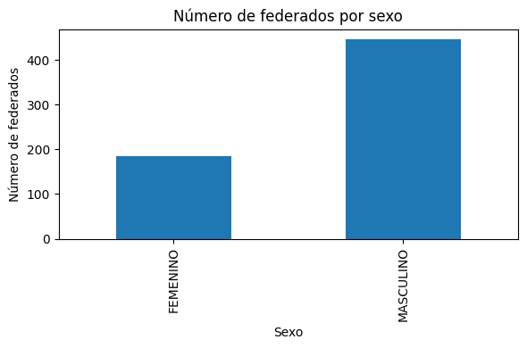

```python
# Gráfico
federados_por_sexo.plot(
    kind="bar",
    figsize=(6, 4),
    title="Número de federados por sexo",
    xlabel="Sexo",
    ylabel="Número de federados"
)

plt.tight_layout()
plt.show()
```

**Interpretación**

El gráfico muestra la distribución del número de federados por sexo. Se observa que uno de los grupos presenta una mayor representación dentro del conjunto total de federados, lo que indica una participación desigual entre hombres y mujeres en la contratación de licencias.

Este resultado no implica necesariamente diferencias en el riesgo o la gravedad de los siniestros, pero proporciona un contexto relevante para la interpretación de análisis posteriores, especialmente aquellos en los que el sexo pueda influir indirectamente en el tipo de actividad realizada o en el perfil del federado.

### Análisis BIVARIANTE

#### Modalidad vs gravedad del accidente

```python
# Tabla: modalidad vs gravedad del accidente

tabla_modalidad_gravedad = pd.crosstab(
    df_analisis["modalidad"],
    df_analisis["descripciongrado"]
)

tabla_modalidad_gravedad
```

| descripciongrado modalidad | GRAVE | LEVE | MORTAL | NAN |
| --- | --- | --- | --- | --- |
| A | 3 | 11 | 0 | 2 |
| A6 | 0 | 3 | 0 | 0 |
| AU | 0 | 4 | 0 | 1 |
| B | 40 | 406 | 6 | 29 |
| B6 | 0 | 4 | 0 | 0 |
| C | 6 | 81 | 0 | 8 |
| D | 8 | 16 | 0 | 2 |
| OT | 0 | 1 | 0 | 0 |

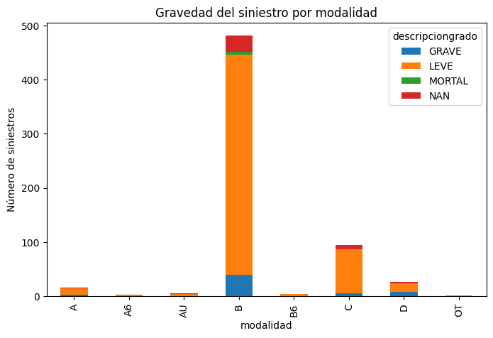

```python
tabla_modalidad_gravedad.plot(
    kind="bar",
    stacked=True,
    figsize=(8,5),
    title="Gravedad del siniestro por modalidad"
)
plt.ylabel("Número de siniestros")
plt.show()
```

**Conclusión**

La tabla de contingencia muestra que la mayoría de los siniestros, con independencia de la modalidad deportiva, corresponden a accidentes de carácter leve.

La modalidad B concentra el mayor número absoluto de siniestros, así como la mayor cantidad de accidentes graves y mortales, lo que es coherente con su mayor volumen de registros en el dataset.

### Indicador clave

#### Tasa de siniestralidad por modalidad

```python
federados_por_modalidad = licencias.groupby("modalidad")["nif"].nunique()
siniestros_por_modalidad = df_analisis.groupby("modalidad")["nif"].count()

tasa_siniestralidad = (
    siniestros_por_modalidad / federados_por_modalidad * 1000
).dropna()

tasa_siniestralidad.sort_values(ascending=False)
```

```
modalidad
D     79.027356
C     62.789161
B     34.376787
A6    23.437500
B6    17.391304
AU     8.605852
A      8.255934
OT     5.235602
Name: nif, dtype: float64
```

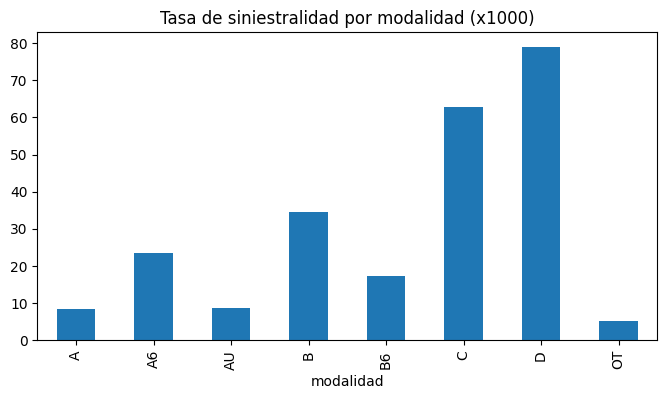

```python
tasa_siniestralidad.plot(
    kind="bar",
    figsize=(8,4),
    title="Tasa de siniestralidad por modalidad (x1000)"
)
plt.show()
```

### Hipótesis A

##### Test Chi-cuadrado

```python
tabla_chi = pd.crosstab(
    df_analisis["modalidad"],
    df_analisis["descripciongrado"]
)

chi2, p, dof, expected = chi2_contingency(tabla_chi)

chi2, p
```

```
(np.float64(25.100232553239024), np.float64(0.24284902642667566))
```

**Interpretación**

El test Chi-cuadrado arroja un p-value = 0.243, superior al nivel de significación habitual (α = 0.05), por lo que no se rechaza la hipótesis nula de independencia.

### Hipótesis B

#### ¿Los federados mayores a 35 años tienen siniestros de mayor gravedad media que los asociados a seguros básicos?

#### Test Kruskal-Wallis

```python
# Mapeo de gravedad a escala ordinal
map_gravedad = {
    "LEVE": 1,
    "GRAVE": 2,
    "MORTAL": 3
}

df_analisis["gravedad_num"] = df_analisis["descripciongrado"].map(map_gravedad)

# Definición de grupos
grupo_mayores_35 = df_analisis[
    (df_analisis["edad"] > 35) &
    (df_analisis["gravedad_num"].notna())
]["gravedad_num"]

grupo_seguro_B = df_analisis[
    (df_analisis["modalidad"] == "B") &
    (df_analisis["gravedad_num"].notna())
]["gravedad_num"]

# Verificación mínima de datos
grupo_mayores_35.shape, grupo_seguro_B.shape
```

```
((464,), (452,))
```

```python
kruskal(grupo_mayores_35, grupo_seguro_B)
```

```
KruskalResult(statistic=np.float64(0.1544197613120842), pvalue=np.float64(0.6943469578571092))
```

**Interpretación**

El test de Kruskal-Wallis no muestra diferencias estadísticamente significativas en la gravedad media de los siniestros entre los federados mayores de 35 años y aquellos con seguro de cobertura nacional (modalidad B), dado que el valor p es superior al nivel de significación del 5 %. Por tanto, la hipótesis planteada no se confirma con los datos analizados.

**Conclusiones del análisis exploratorio y contrastes de hipótesis**

El análisis exploratorio realizado ha permitido relacionar el perfil del federado con las características de los siniestros registrados, integrando información de licencias y partes de accidente en un único dataset analítico.

Respecto a la **Hipótesis B**, que planteaba una mayor gravedad media de los siniestros en federados mayores de 35 años frente a aquellos con seguro de cobertura nacional (modalidad B), el test no paramétrico de Kruskal-Wallis no revela diferencias estadísticamente significativas entre ambos grupos. Por tanto, la hipótesis planteada no se confirma con los datos disponibles.

En conjunto, los resultados obtenidos indican que, para el periodo y la muestra analizados, ni la modalidad del seguro ni la edad del federado constituyen factores determinantes en la gravedad de los siniestros. Estos hallazgos sugieren que la siniestralidad podría estar influida por otros factores no considerados en este estudio, lo que abre la puerta a futuros análisis con variables adicionales.